# Kevin Peng vs. Ryan Namgung, a Basketball Analysis

Kevin Peng

## Overview

My roommate and I have a slight rivalry on the basketball court. In order to determine who is the best, we decided to have a 1v1 match and record stats for each possession. We played the game as first to 50 points, counting shot values as 2-pointers or 3-pointers. Statistics recorded in this project included variables such as shot type, shot number, defense level, and more. The game was filmed and data was extracted from it. When collected, the data was then seperated into two serperate datasets, one for me and one for Ryan, with the same variables for clarity. Ultimately, this research is not only used to determine who is better at basketball. It also provides the opportunity to learn our strengths/weaknesses and analyze tendencies/references on the basketball court. This data will provide us with parts of the game that each of us need to improve on.

## Data dictionary

Here is a data dictionary for the kevin_basketball and ryan_basketball datasets:

### numeric variables

- possession: a numeric variable that determines which possession of the game either Ryan and I are at, independently.
- shot_value: a numeric variable that describes the value of a given shot, a two or a three pointer.
- field_goals_attempted: a numeric variable that describes how many total shots each player has taken.
- field_goals_made: a numeric variable that describes how many total shots each player has made.
- three_pointers_attempted: a numeric variable that describes how many threes each player has taken.
- three_pointers_made: a numeric variable that describes how many threes each player has made.
- score: a numeric variable that keeps track of the score as the game progresses, independent for each player.

### categorical variables

- player_name: a categorical variable that determines who has possession of the ball at a given time. The format will be player’s initials, “K” for Kevin, and “R” for Ryan.
- shot_type: a categorical variable that describes that type of shot taken by a player. Possible options are:
  - “layup”
  - “jumpshot”
  - “fadeaway” (jumpshot with a backwards jump)
- shot_contestion: a categorical variable that describes the level of defense played during the point. Possible levels are “low, medium, high”.
- make_miss: a categorical variable that describes if a shot was made of missed.

The datasets can be read in as follows:

```r
kevin_basketball <- read_csv("https://raw.githubusercontent.com/URstats/stat209-s18-kevpeng/master/kevin_data.csv")
ryan_basketball <- read.csv("https://raw.githubusercontent.com/URstats/stat209-s18-kevpeng/master/ryan_data.csv")
```

| possession | player_name | shot_type | shot_value | shot_contestion | field_goals_attempted | field_goals_made | three_pointers_attempted | three_pointers_made | make_miss | score |
| --- | --- | --- | --- | --- | --- | --- | --- | --- | --- | --- |
| 1 | K | jumpshot | 3 | high | 1 | 0 | 1 | 0 | miss | 0 |
| 2 | K | fadeaway | 2 | med | 2 | 0 | 1 | 0 | miss | 0 |
| 3 | K | jumpshot | 3 | med | 3 | 0 | 2 | 0 | miss | 0 |
| 4 | K | layup | 2 | high | 4 | 0 | 2 | 0 | miss | 0 |
| 5 | K | jumpshot | 3 | med | 5 | 0 | 3 | 0 | miss | 0 |
| 6 | K | jumpshot | 3 | med | 6 | 0 | 4 | 0 | miss | 0 |
| 7 | K | fadeaway | 2 | high | 7 | 0 | 4 | 0 | miss | 0 |
| 8 | K | jumpshot | 3 | low | 8 | 0 | 5 | 0 | miss | 0 |
| 9 | K | jumpshot | 3 | low | 9 | 1 | 6 | 1 | make | 3 |
| 10 | K | fadeaway | 2 | med | 10 | 2 | 6 | 1 | make | 5 |

[output cut: 51 more lines]

| possession | player_name | shot_type | shot_value | shot_contestion | field_goals_attempted | field_goals_made | three_pointers_attempted | three_pointers_made | make_miss | score |
| --- | --- | --- | --- | --- | --- | --- | --- | --- | --- | --- |
| 1 | R | jumpshot | 2 | med | 1 | 0 | 0 | 0 | miss | 0 |
| 2 | R | layup | 2 | high | 2 | 0 | 0 | 0 | miss | 0 |
| 3 | R | jumpshot | 2 | low | 3 | 1 | 0 | 0 | make | 2 |
| 4 | R | layup | 2 | med | 4 | 2 | 0 | 0 | make | 4 |
| 5 | R | jumpshot | 2 | low | 5 | 2 | 0 | 0 | miss | 4 |
| 6 | R | fadeaway | 2 | low | 6 | 3 | 0 | 0 | make | 6 |
| 7 | R | layup | 2 | high | 7 | 3 | 0 | 0 | miss | 6 |
| 8 | R | fadeaway | 2 | low | 8 | 3 | 0 | 0 | miss | 6 |
| 9 | R | jumpshot | 3 | low | 9 | 4 | 1 | 1 | make | 9 |
| 10 | R | layup | 2 | high | 10 | 4 | 1 | 1 | miss | 9 |

[output cut: 48 more lines]

## Exploratory Analysis

### Score Progression

Throughout the game, I knew my strengths were shooting three pointers. As a result, I did my best to shoot as many of them as I can. The following plot shows what value shot I took each possession, along with a line to show what point is victory.

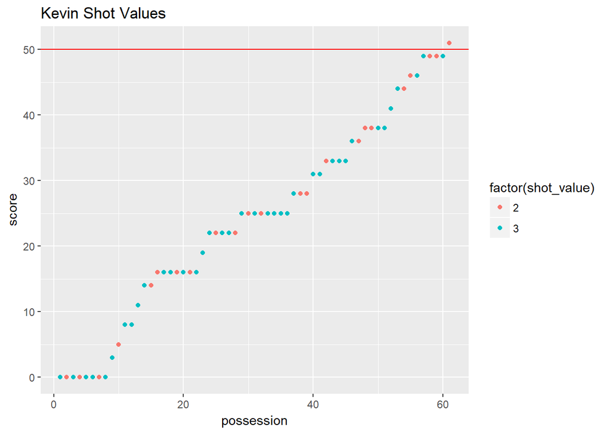

The following plot shows what value shots Ryan took each possession.

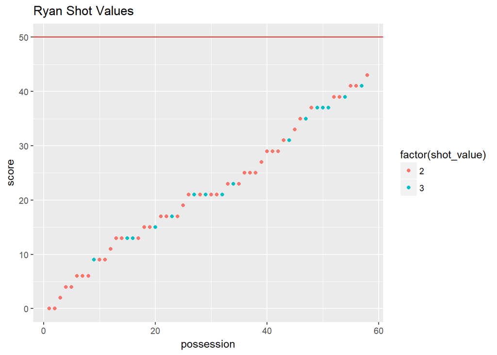

From the data, it can be observed that I win by reaching 50 points first. In addition, while comparing these plots, the score line on mine has steeper slopes than Ryan’s. This is attributed to scoring streaks, where I score multiple buckets in a row. Ryan’s plot has lower shopes because he would not go on scoring streaks, frequently missing after making one.

### 3-Pointers

I decided to dig deeper into the three pointer data. I filtered the data into a new dataset that only contained shots that were 3-pointers. I then plotted it with the shot make/made as an aestetic. I took the data further by filtering it based on shot_contestion, or defense level and examined shooting percentages based on different defense.

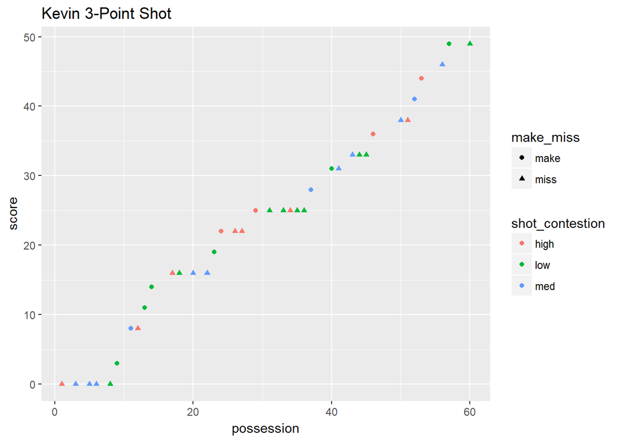

```
## [1] "kevin three pointer %, low defense"
```

```
## [1] 0.4
```

```
## [1] "kevin three pointer %, medium defense"
```

```
## [1] 0.25
```

```
## [1] "kevin three pointer %, high defense"
```

```
## [1] 0.3636364
```

```
## [1] "kevin three pointer %, overall"
```

```
## [1] 0.3684211
```

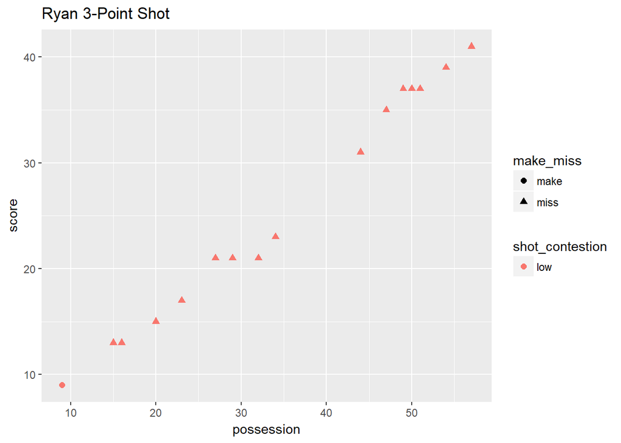

```
## [1] "ryan three pointer %, overall"
```

```
## [1] 0.0625
```

From the data, there is a clear winner, at least in 3-point shooting percentage. Overall, I shot 36.84%, while Ryan shot 6.25%.

I looked at the defense levels ability on my shooting percentages. While the defense level is low, my shooting percentage is the highest, which is to be expected, at 40%. What was surprising was how having medium defense was more detrimental to my shot than high defense, with a 25% chance for medium defense, and a 36% for high defense. Having a high level of defense only dropped my shot by ~4% vs. having low defense. This data suggests that playing the right level of defense is required to decrease my shooting percentage.

For Ryan, all of his 3-point attempts had low defense, so it was not filtered into detail.

### 2-Pointers

I filtered data into only 2-pointers as well. Once filtered to only 2 pointers, I wanted to see how we both fare shooting from inside the 3-point line.

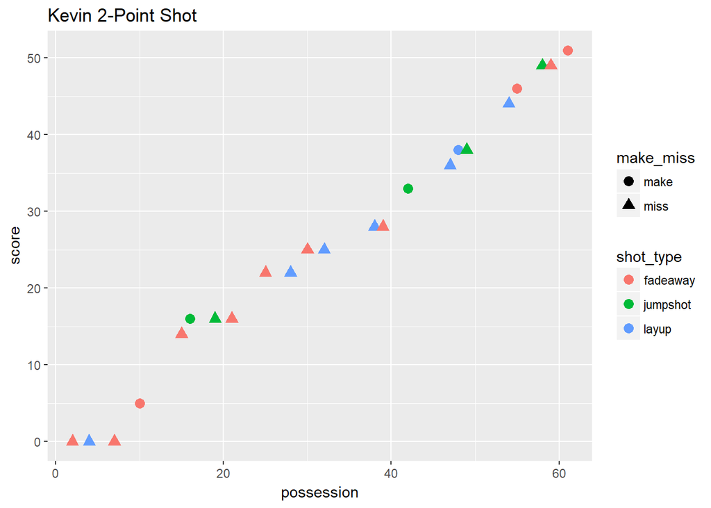

```
## [1] "kevin two pointer %, overall"
```

```
## [1] 0.2608696
```

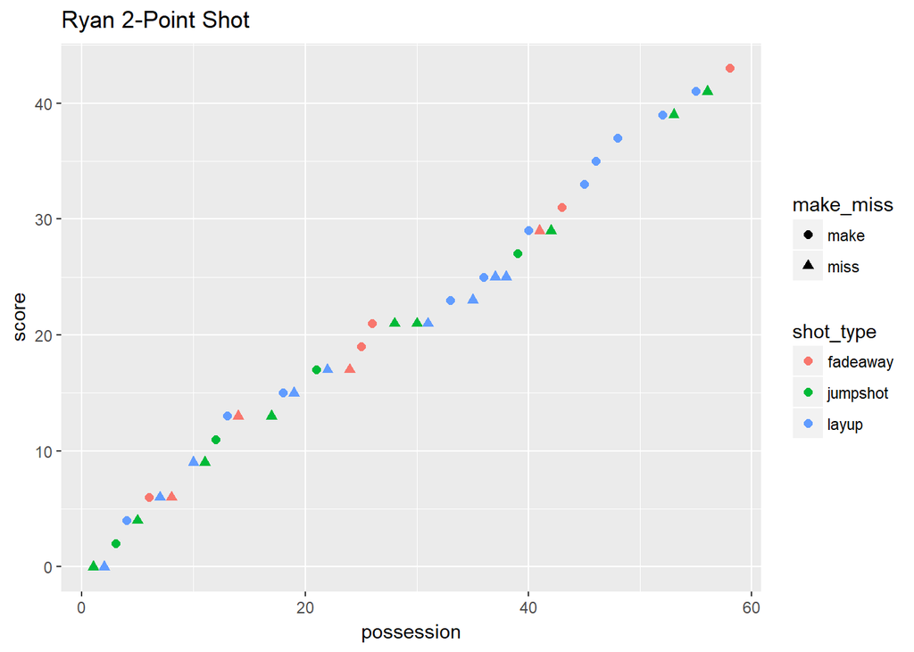

```
## [1] "ryan two pointer %, overall"
```

```
## [1] 0.4761905
```

Based on the data, we are able to see where Ryan gets the majority of his points from. Compared to his 3-point percentage, his 2-point percentage is excellent. His 47.6% is better than my 26% from 2-point range. Additionally, Ryan shot approximately twice as many 2-pointers than I did, 42 to 23. This data shows that Ryan is more comfortable driving in and shooting from close range, and he has the advantage doing so.

## Conclusion

Other variables that I would like to add to this project pertain to misses. I would include which direction the ball missed: left, right, far, or short. From an analysis I would be able to determine how to improve based on which direction was most frequent. For example, if the ball misses left, shoot more right.

Ultimately, basketball is a game of numbers and whoever gets more numbers, will be the winner.

## References

### Special thanks to:

- Joseph Mugisha for lending me his camera to record the game.
- David Qin for recording the battle.
- Ryan Namgung for agreeing to lose.